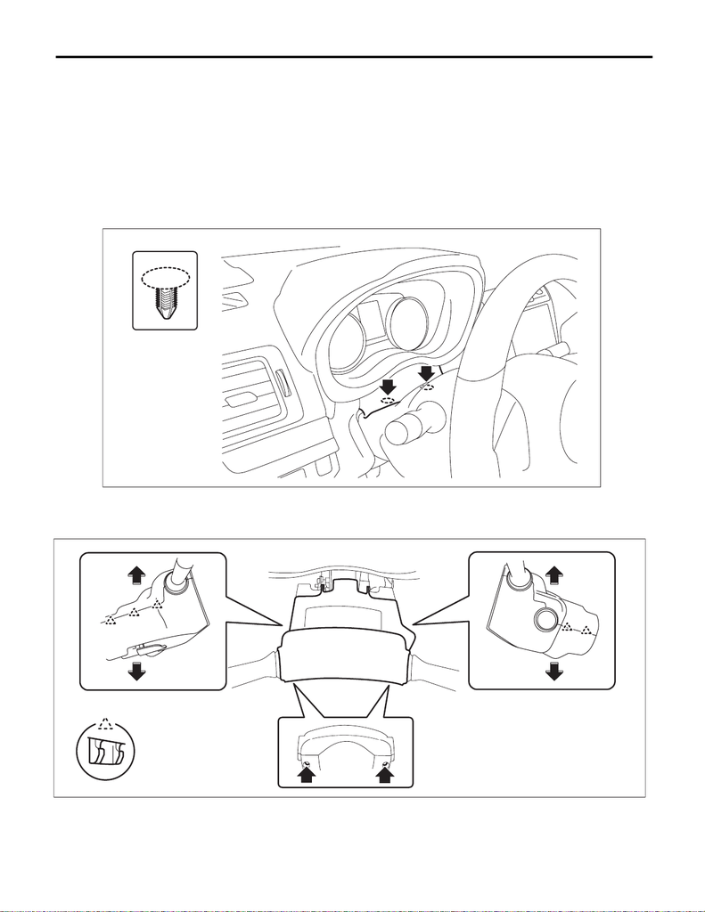

SL-88

Immobilizer Antenna

SECURITY AND LOCKS

28.Immobilizer Antenna

A: REMOVAL

1. MODEL WITHOUT KEYLESS ACCESS

1) Disconnect the ground cable from battery and wait for at least 60 seconds before starting work. <Ref. to

NT-5, BATTERY, NOTE, Note.>

NOTE:

For models other than STI model, disconnect the ground terminal from battery sensor.

2) Remove the cover assembly - column.

(1) Remove the clips, and remove the cover - column.

(2) Remove the screws by turning the steering wheel to right and left.

(3) Release the claw, and remove the cover assembly - column UPR and the cover assembly - column

LWR.

PS-01710

LI-01207

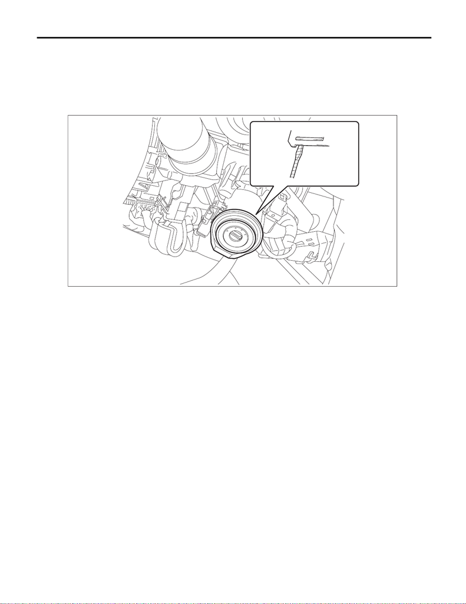

SL-89

Immobilizer Antenna

SECURITY AND LOCKS

3) Remove the immobilizer antenna assembly.

(1) Disconnect the connector.

(2) Release two claws using a flat tip screwdriver or similar tool wrapped with a protection tape, and re-

move the immobilizer antenna assembly.

CAUTION:

Do not apply excessive force to disengage the lock of immobilizer antenna assembly. Otherwise they

may be broken because those parts are the products made of a plastic.

SL-02667

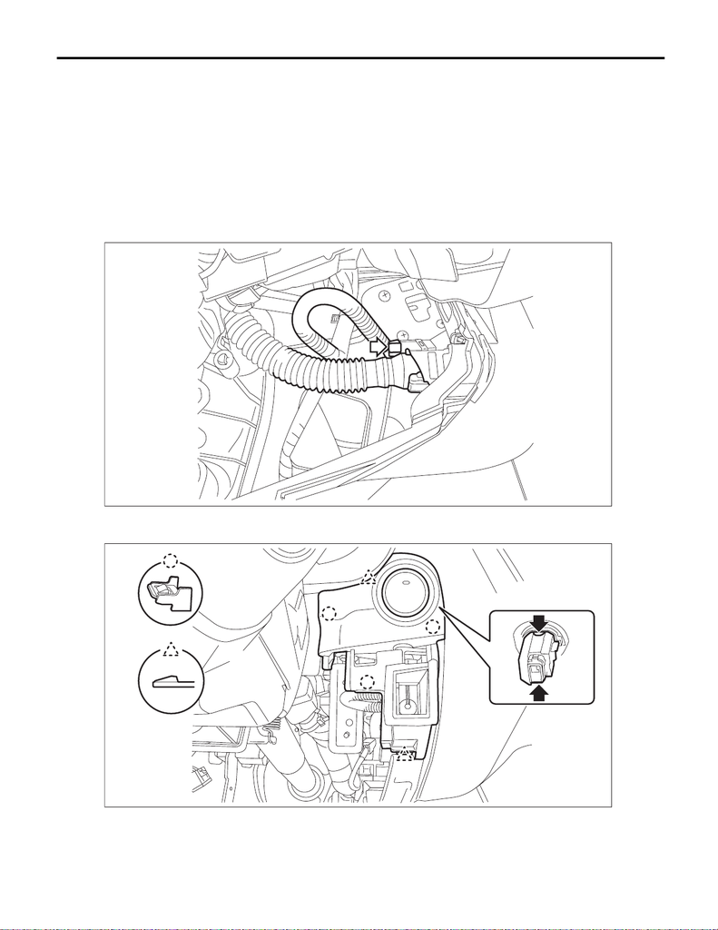

SL-90

Immobilizer Antenna

SECURITY AND LOCKS

2. MODEL WITH KEYLESS ACCESS

NOTE:

Immobilizer antenna is integrated with the push button ignition switch.

1) Disconnect the ground cable from battery and wait for at least 60 seconds before starting work. <Ref. to

NT-5, BATTERY, NOTE, Note.>

NOTE:

For models other than STI model, disconnect the ground terminal from battery sensor.

2) Remove the cover assembly - instrument panel LWR driver. <Ref. to EI-61, REMOVAL, Instrument Panel

Lower Cover.>

3) Remove the push button ignition switch.

(1) Disconnect the connector, and remove the aspirator hose.

(2) Release the claws, and then remove the panel - switch.

(3) Release the claws, and then remove the push button ignition switch from the panel - switch.

AC-02714

SL-01599

[figure not shown]

SL-91

Immobilizer Antenna

SECURITY AND LOCKS

B: INSTALLATION

1. MODEL WITHOUT KEYLESS ACCESS

1) Install the immobilizer antenna assembly.

2) Install the cover assembly - column.

3) Connect the battery ground terminal. <Ref. to NT-5, BATTERY, NOTE, Note.>

NOTE:

For models other than STI model, connect the ground terminal to battery sensor.

2. MODEL WITH KEYLESS ACCESS

1) Install the push button ignition switch to the cover assembly - instrument panel LWR driver INN.

2) Install the cover assembly - instrument panel LWR driver.

3) Connect the battery ground terminal. <Ref. to NT-5, BATTERY, NOTE, Note.>

NOTE:

For models other than STI model, connect the ground terminal to battery sensor.